# Group comparisons

Nurlan Dauletbayev

2023-12-11

It is very common to complement the descriptive analyses with group comparisions. This can be done using the parametric t test (for paired and unpaired two-group comparisons) or ANOVA test (for a three-group comparison). An unpaired t-test is carried out when two independent variables are to be compared (example: age comparison between female and male patients in the “Cleveland” training dataset). This will be shown in this session.

This session will necessitate the use of one package. The installation and activation of this packages is done as follows:

If the package “DescTools” is not installed yet in your R, please install and activate it using the following command line.

```r
install.packages("DescTools", repos = "http://cran.us.r-project.org")
library(DescTools)
```

Then, our usual training dataset (“Cleveland…”) should be imported.

```r
myData <- read.csv(file.choose())
head(myData)
```

```
##   age    sex          cp trestbps chol   fbs            restecg thalach exang
## 1  63   male  typ_angina      145  233  TRUE left_ventr_hypertr     150    No
## 2  67   male      asympt      160  286 FALSE left_ventr_hypertr     108   Yes
## 3  67   male      asympt      120  229 FALSE left_ventr_hypertr     129   Yes
## 4  37   male  non_angina      130  250 FALSE           norm_ecg     187    No
## 5  41 female atyp_angina      130  204 FALSE left_ventr_hypertr     172    No
## 6  56   male atyp_angina      120  236 FALSE           norm_ecg     178    No
##   oldpeak     slope        ca         thal             num
## 1     2.3 downslope 0_vessels fixed_defect       no_narrow
## 2     1.5      flat 3_vessels       normal moderate_narrow
## 3     2.6      flat 2_vessels   rev_defect     mild_narrow
## 4     3.5 downslope 0_vessels       normal       no_narrow
## 5     1.4   upslope 0_vessels       normal       no_narrow
## 6     0.8   upslope 0_vessels       normal       no_narrow
```

```r
tail(myData)
```

```
##     age    sex          cp trestbps chol   fbs            restecg thalach exang
## 189  55 female      asympt      128  205 FALSE        ST-T_abnorm     130   Yes
## 190  58 female      asympt      170  225  TRUE left_ventr_hypertr     146   Yes
## 191  55 female atyp_angina      132  342 FALSE           norm_ecg     166    No
## 192  63 female      asympt      124  197 FALSE           norm_ecg     136   Yes
## 193  57 female      asympt      140  241 FALSE           norm_ecg     123   Yes
## 194  57 female atyp_angina      130  236 FALSE left_ventr_hypertr     174    No
##     oldpeak   slope        ca         thal             num
## 189     2.0    flat 1_vessels   rev_defect   severe_narrow
## 190     2.8    flat 2_vessels fixed_defect moderate_narrow
## 191     1.2 upslope 0_vessels       normal       no_narrow
## 192     0.0    flat 0_vessels       normal     mild_narrow
## 193     0.2    flat 0_vessels   rev_defect     mild_narrow
## 194     0.0    flat 1_vessels       normal     mild_narrow
```

```r
dim(myData)
```

```
## [1] 194  14
```

```r
class(myData)
```

```
## [1] "data.frame"
```

```r
sum(is.na(myData))
```

```
## [1] 1
```

```r
colSums(is.na(myData)) # you should pay attention to this new function; it shows the variables with missed values
```

```
##      age      sex       cp trestbps     chol      fbs  restecg  thalach
##        0        0        0        0        0        0        0        0
##    exang  oldpeak    slope       ca     thal      num
##        0        0        0        0        1        0
```

```r
myData1 <- na.omit(myData)
dim(myData1)
```

```
## [1] 193  14
```

```r
colSums(is.na(myData1))
```

```
##      age      sex       cp trestbps     chol      fbs  restecg  thalach
##        0        0        0        0        0        0        0        0
##    exang  oldpeak    slope       ca     thal      num
##        0        0        0        0        0        0
```

this modifies the type of the variable “sex”, since this variable will be used in some of the subsequent analyses

```r
class(myData1$sex)
```

```
## [1] "character"
```

```r
myData1$sex <- as.factor(myData1$sex)
class(myData1$sex)
```

```
## [1] "factor"
```

```r
levels(myData1$sex)
```

```
## [1] "female" "male"
```

# A. Two-group comparisons

There are two options how unpaired t-test can be applied.

Option 1 (estimates the statistical significance of age difference between female and male patients):

```r
t.test.1 <- t.test(formula = age ~ sex, data = myData1)
print(t.test.1)
```

```
##
##  Welch Two Sample t-test
##
## data:  age by sex
## t = 1.6499, df = 188.64, p-value = 0.1006
## alternative hypothesis: true difference in means between group female and group male is not equal to 0
## 95 percent confidence interval:
##  -0.4168538  4.6797404
## sample estimates:
## mean in group female   mean in group male
##             55.75000             53.61856
```

The output “p-value = 0.1006” indicates the absence of statistical significance. Please note that extreme small p-values can sometimes be written as scientific notation (e.g., “p-value < 2.2e-16”). The latter example indicates that the p value is less than 2.2 x 10^-16 (that is, less than 0.00000000000000022), which indicates a significant difference.

Another option to use the “t.test” function is as follows (the argument “paired = FALSE” indicates the unpaired test):

```r
t.test.2 <- t.test(myData$trestbps, myData$chol, paired = FALSE)
print(t.test.2)
```

```
##
##  Welch Two Sample t-test
##
## data:  myData$trestbps and myData$chol
## t = -28.399, df = 231.56, p-value < 2.2e-16
## alternative hypothesis: true difference in means is not equal to 0
## 95 percent confidence interval:
##  -126.4348 -110.0291
## sample estimates:
## mean of x mean of y
##  131.5515  249.7835
```

In this option, two different variables are compared without stratification by groups.

Often, we want to carry out paired t-test. An example for this is when the patient values after the treatment are compared with patient values before the treatment. For this comparisons, we will create a new dataset, since the “Cleveland” dataset only permits unpaired comparisons.

```r
CholBeforeStatins <- myData1$chol
class(CholBeforeStatins)
```

```
## [1] "integer"
```

```r
length(CholBeforeStatins)
```

```
## [1] 193
```

```r
head(CholBeforeStatins)
```

```
## [1] 233 286 229 250 204 236
```

```r
tail(CholBeforeStatins)
```

```
## [1] 205 225 342 197 241 236
```

To create simulated values of cholsterol after the treatment, 193 random numbers will be generated and subtracted from the vector “CholBeforeStatins”. Function “rnorm()” of base R will be used to randomly generate a vector of 193 random numbers normally distributed around a given average value (“mean”), with a pre-defined standard deviation (“sd”). You should try to change the values of “mean” and “sd”, and test the vector:

```r
RandomNumbers_vector <- rnorm(193, mean = 2, sd = 0.1)
head(RandomNumbers_vector)
```

```
## [1] 2.002249 2.133973 1.845502 1.894342 1.872041 2.124002
```

```r
tail(RandomNumbers_vector)
```

```
## [1] 1.840469 1.945479 1.981816 1.947039 1.893279 2.114194
```

This will show the distribution of the values in this vector

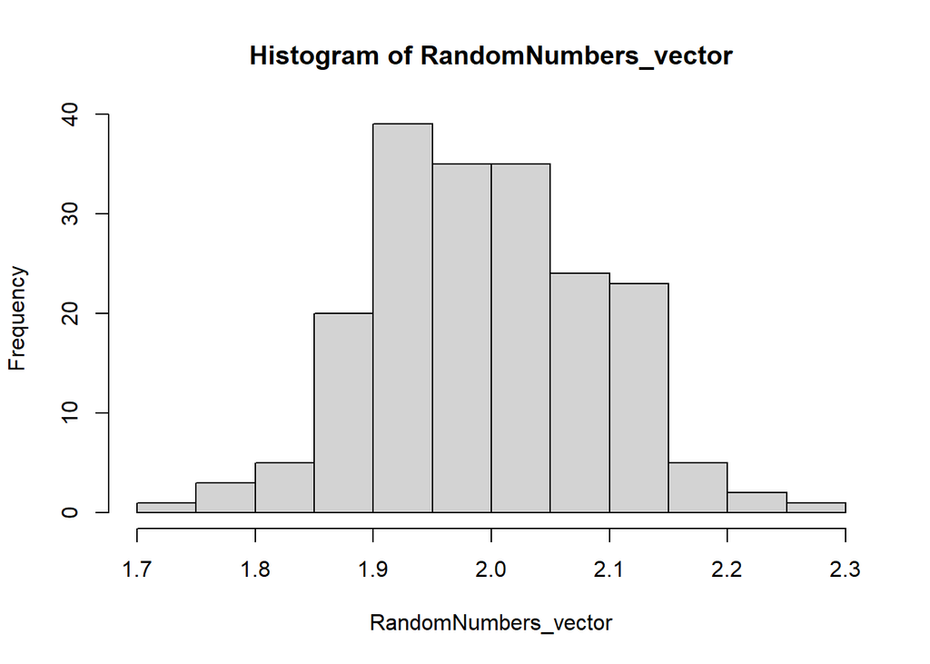

```r
hist(RandomNumbers_vector)
```

Now we can subtract this random vector from the cholesterol values from before the treatment:

```r
CholAfterStatins <- CholBeforeStatins - RandomNumbers_vector
length(CholAfterStatins)
```

```
## [1] 193
```

```r
head(CholAfterStatins)
```

```
## [1] 230.9978 283.8660 227.1545 248.1057 202.1280 233.8760
```

```r
tail(CholAfterStatins)
```

```
## [1] 203.1595 223.0545 340.0182 195.0530 239.1067 233.8858
```

We will combine both cholecterol vectors (before and after the treatment) into a data frame:

```r
CholTreatmentData <- cbind.data.frame(CholBeforeStatins,
                                      CholAfterStatins)
dim(CholTreatmentData)
```

```
## [1] 193   2
```

```r
head(CholTreatmentData)
```

```
##   CholBeforeStatins CholAfterStatins
## 1               233         230.9978
## 2               286         283.8660
## 3               229         227.1545
## 4               250         248.1057
## 5               204         202.1280
## 6               236         233.8760
```

```r
tail(CholTreatmentData)
```

```
##     CholBeforeStatins CholAfterStatins
## 188               205         203.1595
## 189               225         223.0545
## 190               342         340.0182
## 191               197         195.0530
## 192               241         239.1067
## 193               236         233.8858
```

Now we can carry out the paired t-test to compare the cholesterol values before and after the treatment.

```r
t.test.3 <- t.test(CholTreatmentData$CholAfterStatins,
                     CholTreatmentData$CholBeforeStatins, paired = TRUE)
print(t.test.3)
```

```
##
##  Paired t-test
##
## data:  CholTreatmentData$CholAfterStatins and CholTreatmentData$CholBeforeStatins
## t = -293.93, df = 192, p-value < 2.2e-16
## alternative hypothesis: true difference in means is not equal to 0
## 95 percent confidence interval:
##  -2.008441 -1.981666
## sample estimates:
## mean of the differences
##               -1.995054
```

Is the difference between cholesterol values before and after the treatment statistically significant?

When we deal with the data that are not normally distributed, it is common to use non-parametric tests, such as Wilcoxon test for paired comparisons and Mann-Whitney test for unpared comparisons. One way how to test for normal distribution is shown above, with the histogram. Another popular methods are based on calculations, either by the Shapiro-Wilk or Kolmogorov-Smirnov test. The following will demonstrate all three methods with regard to the age variable.

First, the dataset will be subset for female and male patients

```r
myData1_female <- myData1[which(myData1$sex == "female"), ]
dim(myData1_female)
```

```
## [1] 96 14
```

```r
myData1_male <- myData1[which(myData1$sex == "male"), ]
dim(myData1_male)
```

```
## [1] 97 14
```

Then, the age (of either female or male patients) will be saved in separate vectors

```r
# first, female patients
Age_female <- myData1_female$age
head(Age_female)
```

```
## [1] 41 62 57 56 48 58
```

```r
tail(Age_female)
```

```
## [1] 55 58 55 63 57 57
```

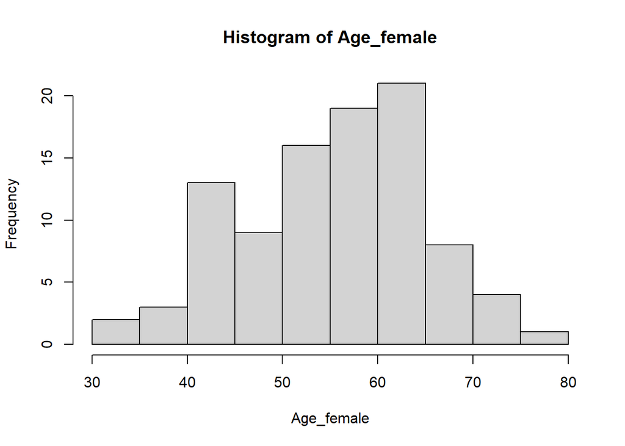

```r
hist(Age_female)
```

```r
Shapiro_Age_female <- shapiro.test(Age_female)
print(Shapiro_Age_female)
```

```
##
##  Shapiro-Wilk normality test
##
## data:  Age_female
## W = 0.9778, p-value = 0.1028
```

If the p-value is higher 0.05, then the data distribution in the vector is close to normal. This makes sense because the histogram also showed the data distribution close to “bell-shaped”.

```r
# next, male patients
Age_male <- myData1_male$age
head(Age_male)
```

```
## [1] 63 67 67 37 56 63
```

```r
tail(Age_male)
```

```
## [1] 54 51 29 51 70 62
```

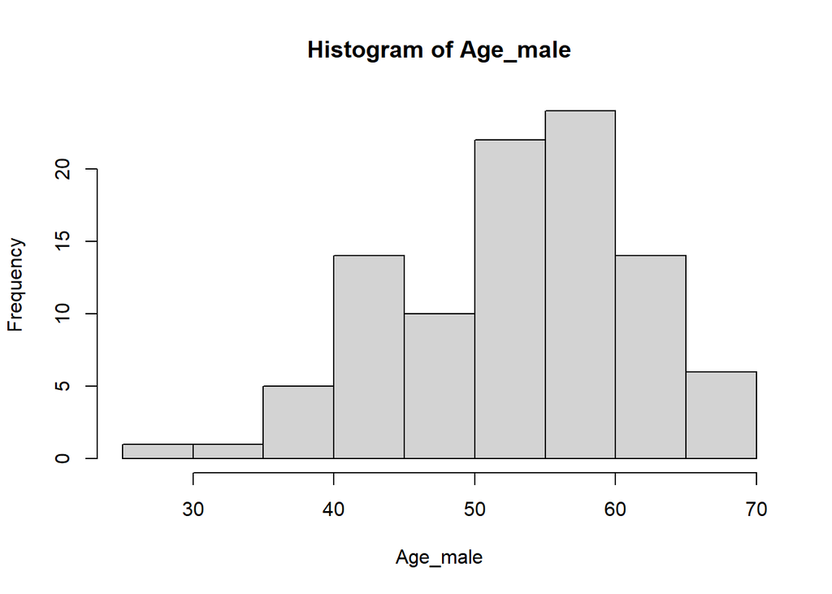

```r
hist(Age_male)
```

```r
Shapiro_Age_male <- shapiro.test(Age_male)
print(Shapiro_Age_male)
```

```
##
##  Shapiro-Wilk normality test
##
## data:  Age_male
## W = 0.97926, p-value = 0.1283
```

```r
KS_Age_female <- ks.test(Age_female, "pnorm")
print(KS_Age_female)
```

```
##
##  One-sample Kolmogorov-Smirnov test
##
## data:  Age_female
## D = 1, p-value < 2.2e-16
## alternative hypothesis: two-sided
```

```r
KS_Age_male <- ks.test(Age_male, "pnorm")
print(KS_Age_male)
```

```
##
##  One-sample Kolmogorov-Smirnov test
##
## data:  Age_male
## D = 1, p-value < 2.2e-16
## alternative hypothesis: two-sided
```

The argument “pnorm” in this function indicates that the comparison should be with a theoretical normal distribution.

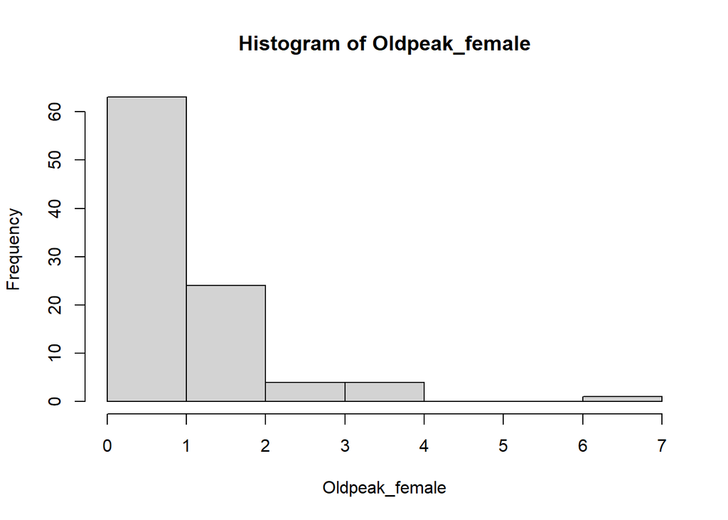

```r
# female patients
Oldpeak_female <- myData1_female$oldpeak
hist(Oldpeak_female)
```

```r
Shapiro_Oldpeak_female <- shapiro.test(Oldpeak_female)
print(Oldpeak_female)
```

```
##  [1] 1.4 3.6 0.6 1.3 0.2 1.0 1.6 0.0 2.6 1.8 1.0 0.4 0.0 0.8 0.0 1.2 1.4 0.0 0.8
## [20] 0.8 1.5 0.4 0.0 0.5 6.2 0.6 0.0 2.6 0.0 0.0 1.0 3.0 1.2 1.4 4.0 0.6 4.0 0.0
## [39] 0.2 1.4 0.0 0.6 1.6 1.6 1.0 0.0 0.0 0.0 1.2 1.9 0.0 0.0 1.9 1.5 0.2 1.1 0.0
## [58] 0.0 0.2 1.4 0.0 1.0 0.0 0.0 2.0 0.0 0.0 0.0 1.8 0.7 0.0 0.1 3.4 0.2 0.0 0.0
## [77] 0.0 0.0 0.0 0.6 0.0 0.3 1.1 0.3 0.0 0.9 1.6 0.0 0.0 0.6 2.0 2.8 1.2 0.0 0.2
## [96] 0.0
```

```r
KS_Oldpeak_female <- ks.test(Oldpeak_female, "pnorm")
print(KS_Oldpeak_female)
```

```
##
##  One-sample Kolmogorov-Smirnov test
##
## data:  Oldpeak_female
## D = 0.5, p-value < 2.2e-16
## alternative hypothesis: two-sided
```

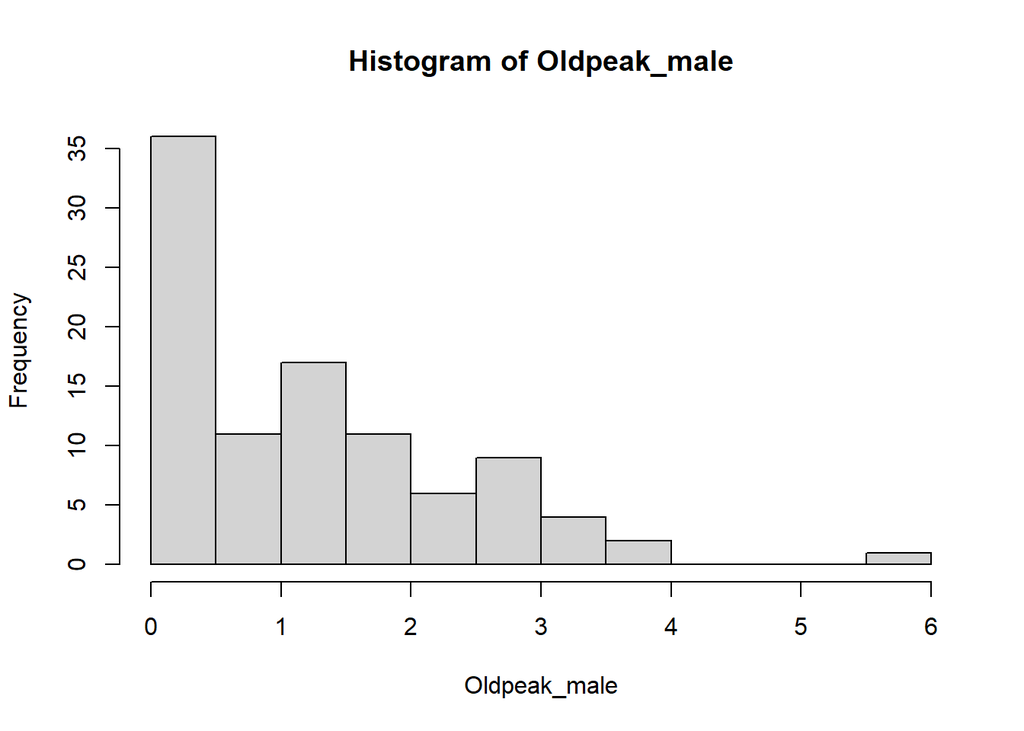

```r
# male patients
Oldpeak_male <- myData1_male$oldpeak
hist(Oldpeak_male)
```

```r
Shapiro_Oldpeak_male <- shapiro.test(Oldpeak_male)
print(Oldpeak_male)
```

```
##  [1] 2.3 1.5 2.6 3.5 0.8 1.4 3.1 0.4 0.6 0.0 0.5 1.6 1.0 1.2 0.6 1.8 1.8 3.2 2.4
## [20] 1.5 2.0 1.4 0.0 0.5 0.4 0.0 2.5 0.6 1.2 1.0 1.4 1.6 2.5 0.6 2.6 1.2 0.4 0.0
## [39] 0.0 1.4 2.2 0.6 0.0 0.5 1.4 2.2 1.4 2.8 3.0 1.6 3.4 3.6 0.2 1.8 0.6 0.0 2.8
## [58] 0.2 0.8 3.0 0.0 1.6 0.2 0.0 0.0 0.4 1.8 0.0 1.2 0.8 0.0 0.0 0.0 2.0 0.0 0.0
## [77] 0.4 3.6 1.2 1.2 0.0 0.0 0.0 1.8 2.8 0.0 1.2 5.6 1.4 2.8 0.0 0.4 0.0 0.0 0.0
## [96] 2.6 1.4
```

```r
KS_Oldpeak_male <- ks.test(Oldpeak_male, "pnorm")
print(KS_Oldpeak_male)
```

```
##
##  One-sample Kolmogorov-Smirnov test
##
## data:  Oldpeak_male
## D = 0.5, p-value < 2.2e-16
## alternative hypothesis: two-sided
```

Since “oldpeak” values are not normally distributed in both female and male patients, Mann-Whitney test will be used. This test is a modification of Wilcoxon test, so do not be surprised that the function is called “wilcox.test”

```r
Wilcox.test.1 <- wilcox.test(formula = oldpeak ~ sex, data = myData1)
print(Wilcox.test.1)
```

```
##
##  Wilcoxon rank sum test with continuity correction
##
## data:  oldpeak by sex
## W = 3708.5, p-value = 0.01322
## alternative hypothesis: true location shift is not equal to 0
```

The p-value indicates statistical difference (p = 0.01322). It is useful to combine the comparative analysis with a descriptive analysis (such as, boxplot) to visualize the estimated statistical differences:

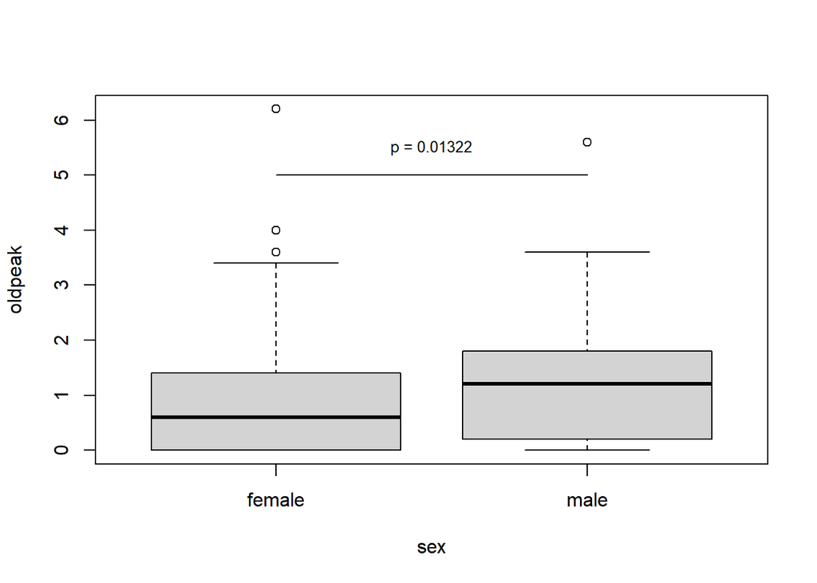

```r
boxplot(formula = oldpeak ~ sex, data = myData1)
# try to deduce what these programming lines do
segments(x0 = 1, x1 = 2, y0 = 5, y1 = 5)
text(x = 1.5, y = 5.5,
     labels = "p = 0.01322",
     cex = 0.8)
```

Please try to apply Mann-Whitney test as t-test, option 2.

When this unparametric test is applied as paired test, it is called Wilcoxon test. It is confusing, so just try to memorize the respective use of this test!

We will next apply Wilcoxon (i.e., paired) test to the previously created data frame of cholesterol values before and after treatment.

```r
Wilcox.test.2 <- wilcox.test(CholTreatmentData$CholAfterStatins,
                     CholTreatmentData$CholBeforeStatins, paired = TRUE)
print(Wilcox.test.2)
```

```
##
##  Wilcoxon signed rank test with continuity correction
##
## data:  CholTreatmentData$CholAfterStatins and CholTreatmentData$CholBeforeStatins
## V = 0, p-value < 2.2e-16
## alternative hypothesis: true location shift is not equal to 0
```

Please answer the question whether this test indicated a statistical difference.

# B. Three-group comparisons

The one-way ANOVA test compares three or more groups. The best way to apply this test is to use a similar “formula”-based method, in which there is one analyzed variable followed by the “~” sign, and the groups are defined by a different variable. In the dataset “Cleveland”, a three-group analysis can be done based on the variable “cp” that has four classes. We will first need to transform this variable into a categorical variable.

```r
myData1$cp <- as.factor(myData1$cp)
levels(myData1$cp)
```

```
## [1] "asympt"      "atyp_angina" "non_angina"  "typ_angina"
```

We will analyze the variable “oldpeak”, as to whether there is a significant differences among groups defined by the variable “cp”. It is always helpful to first visualize the data:

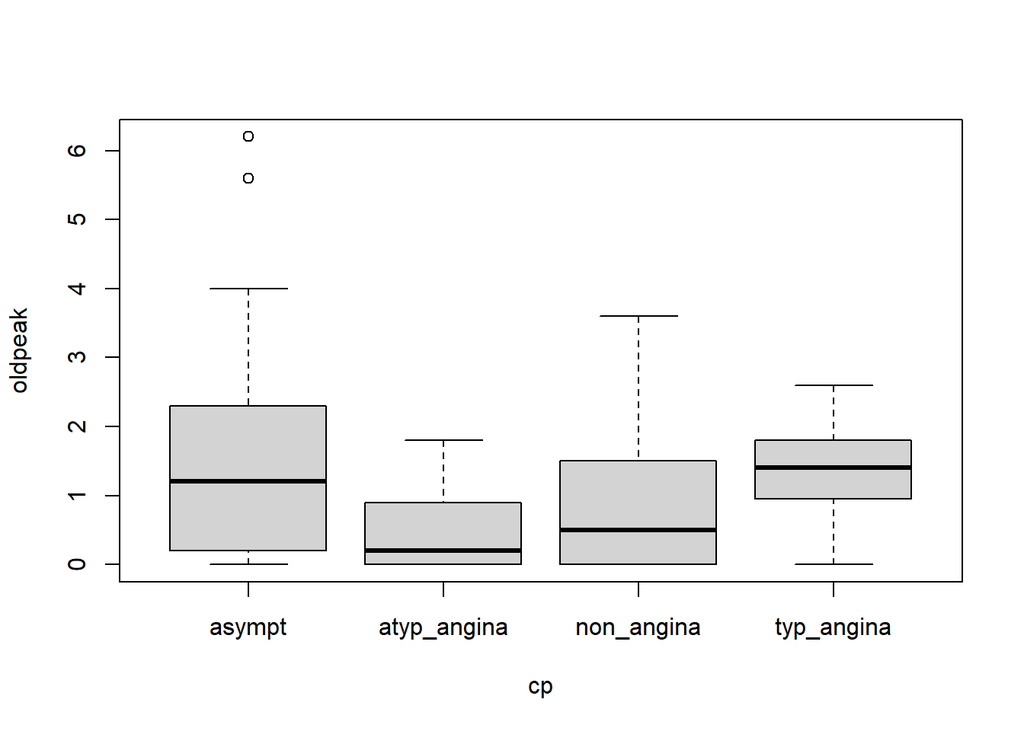

```r
boxplot(formula = oldpeak ~ cp, data = myData1)
```

It appears that at least one group (“atyp_angina”) shows lower values of “oldpeak”. Let’s carry out ANOVA test using function “aov()”.

```r
ANOVA_test <- aov(formula = oldpeak ~ cp, data = myData1)
print(ANOVA_test)
```

```
## Call:
##    aov(formula = oldpeak ~ cp, data = myData1)
##
## Terms:
##                        cp Residuals
## Sum of Squares   26.56014 227.67665
## Deg. of Freedom         3       189
##
## Residual standard error: 1.09756
## Estimated effects may be unbalanced
```

```r
summary(ANOVA_test)
```

```
##              Df Sum Sq Mean Sq F value  Pr(>F)
## cp            3  26.56   8.853   7.349 0.00011 ***
## Residuals   189 227.68   1.205
## ---
## Signif. codes:  0 '***' 0.001 '**' 0.01 '*' 0.05 '.' 0.1 ' ' 1
```

Important comment: unlike with previous t-test and Wilcoxon / Mann-Whitney tests, the output of ANOVA test differs whether it is printed using “print()” function or “summary()” function. I usually recommend to use the “summary()” function with ANOVA result. The p-value is demonstrated below the “Pr(>F)” (here: 0.00011).

ANOVA test only indicates that there is a statistical difference among groups. To find out which group(s) is/are statistically different, we will need to apply a post-hoc test. In my research, I usually utilize Tukey HSD test, which adjusts for multiple comparisons. This test uses the output of ANOVA test and carries out pairwise comparisons among groups, such as shown below:

```r
Tukey_test <- TukeyHSD(ANOVA_test)
print(Tukey_test)
```

```
##   Tukey multiple comparisons of means
##     95% family-wise confidence level
##
## Fit: aov(formula = oldpeak ~ cp, data = myData1)
##
## $cp
##                               diff        lwr        upr     p adj
## atyp_angina-asympt     -0.93721591 -1.5244934 -0.3499384 0.0003074
## non_angina-asympt      -0.60263930 -1.0743519 -0.1309266 0.0060712
## typ_angina-asympt      -0.08181818 -0.9916246  0.8279882 0.9955262
## non_angina-atyp_angina  0.33457661 -0.2846679  0.9538211 0.5006175
## typ_angina-atyp_angina  0.85539773 -0.1389355  1.8497310 0.1189443
## typ_angina-non_angina   0.52082111 -0.4099402  1.4515824 0.4696662
```

The results of Tukey HSD test indicate statistical significance in two comparisons “atyp_angina - asympt” (p adj = 0.0003074) and “non_angina - asympt” (p adj = 0.0060712). The “p adj” stands for “p-value adjusted for multiple comparisons”.

If the group comparison is to be done by a non-parametric test, then Kruskal-Wallis test should be used. This is done as follows.

```r
Kruskal_test <- kruskal.test(formula = oldpeak ~ cp, data = myData1)
print(Kruskal_test)
```

```
##
##  Kruskal-Wallis rank sum test
##
## data:  oldpeak by cp
## Kruskal-Wallis chi-squared = 18.404, df = 3, p-value = 0.000363
```

Also this test indicates statistical significance in “oldpeak” values among the groups in the variable “cp”. Dunn’s test is an appropriate post-hoc test to follow up Kruskal-Wallis test. Dunn’s test allows for a wide selection of adjustment methods to correct p-values for multiple comparisons. There is no consensus, but Bonferroni correction for multiple comparisons seems to be widely acceptable.

Dunn’s test is not part of base R functions, so we will need to use this function “DunnTest” of the “DescTools” package (which you have installed above).

```r
Dunn_test <- DescTools::DunnTest(oldpeak ~ cp, data = myData1,
                                 method = "bonferroni")
print(Dunn_test)
```

```
##
##  Dunn's test of multiple comparisons using rank sums : bonferroni
##
##                        mean.rank.diff    pval
## atyp_angina-asympt         -42.849432 0.00097 ***
## non_angina-asympt          -24.671004 0.04108 *
## typ_angina-asympt            7.005682 1.00000
## non_angina-atyp_angina      18.178427 0.77433
## typ_angina-atyp_angina      49.855114 0.05718 .
## typ_angina-non_angina       31.676686 0.47077
## ---
## Signif. codes:  0 '***' 0.001 '**' 0.01 '*' 0.05 '.' 0.1 ' ' 1
```

Please compare the p-values (“pval”) in the table with the results of Tukey HSD test. Are the results of Dunn’s test and Tukey HSD comparable or different?